# Looking up values in R using `dplyr` and `findInterval`

Joseph S. Tabadero, Jr.

April 15, 2017

## Introduction

My friend, Wilson Chua, was trying to merge two data sets in R in which a value in the variable `SrcIP` (to be explained in a minute) is to be matched with an indicator variable `ASNUM` which is assigned to a range of values with `begin_ip_num` as the lower limit and `end_ip_num` as the upper limit.

I have a similar problem before in which I attempted to use R to match a numerical rating to intervals of scores for rating my students. That was easily solved by using the base function `cut`. But one of the data sets Wilson was working had 1,770,665 rows and at least 9 columns. When I attempted a `cut` solution to his problem, the object created exceeded my computer’s physical memory.

So I did some searching and came upon a function in the `base` package that I have rarely used: `findInterval`.

## A demonstration with small data sets.

From the documentation of `findInterval`, `findInterval(x, vec)`:

```
   Given a vector of non-decreasing breakpoints in vec, find the interval containing each element of x
```

The output of `findInterval` is a vector of increasing index numbers *i*. An element of `x` having the index number `i` belongs to the interval to which `findInterval` assigned that index number `i`.

Suppose we have closed intervals $[3,5]$, $[6,10]$, and $[12, 15]$ which are assigned assigned the values `AS1`, `AS2`, and `AS3`. Note that the intervals do not cover all of the numbers 1 to 18. We want to assign one of `AS1`, `AS2`, and `AS3` to each value of `x` whenever that value falls in the corresponding interval. What we can do is find the intervals defined by the break points `u` (the lower limits) and find the intervals defined by the break points `v` (the upper limits). We have to add 1 to `v` though in order to ensure that `v` doesn’t belong to the interval with lower limit `v + 1`.

```r
x <- 1:18
u <- c(3,6,12)
v <- c(5,10,15)
data1 <- data.frame(x, loc_lower = findInterval(x, u), loc_upper = findInterval(x, v + 1))
data1
```

```
##     x loc_lower loc_upper
## 1   1         0         0
## 2   2         0         0
## 3   3         1         0
## 4   4         1         0
## 5   5         1         0
## 6   6         2         1
## 7   7         2         1
## 8   8         2         1
## 9   9         2         1
## 10 10         2         1
## 11 11         2         2
## 12 12         3         2
## 13 13         3         2
## 14 14         3         2
## 15 15         3         2
## 16 16         3         3
## 17 17         3         3
## 18 18         3         3
```

Next, we create the second data set which has a unique identifier `ASNUM` for each pair of index numbers `loc_lower` and `loc_upper`.

```r
data2 <- data.frame(
  # find the index numbers for values above the lower limits
  loc_lower = findInterval(u, u),
  # find the index numbers for values above the upper limits
  loc_upper = findInterval(u, v + 1),
  ASNUM = c("AS1", "AS2", "AS3")
)
data2
```

```
##   loc_lower loc_upper ASNUM
## 1         1         0   AS1
## 2         2         1   AS2
## 3         3         2   AS3
```

To merge the data, we can use `dplyr::left_join`.

```r
library(tidyverse)
data3 <- left_join(data1, data2, by = c("loc_lower", "loc_upper"))
data3
```

```
##     x loc_lower loc_upper ASNUM
## 1   1         0         0  <NA>
## 2   2         0         0  <NA>
## 3   3         1         0   AS1
## 4   4         1         0   AS1
## 5   5         1         0   AS1
## 6   6         2         1   AS2
## 7   7         2         1   AS2
## 8   8         2         1   AS2
## 9   9         2         1   AS2
## 10 10         2         1   AS2
## 11 11         2         2  <NA>
## 12 12         3         2   AS3
## 13 13         3         2   AS3
## 14 14         3         2   AS3
## 15 15         3         2   AS3
## 16 16         3         3  <NA>
## 17 17         3         3  <NA>
## 18 18         3         3  <NA>
```

We note that since `x = 1` does not belong to the intervals that we have defined earlier, its `ASNUM` is `NA`.

## Is there a better solution?

There must be, for instance using [`data.table`](http://stackoverflow.com/questions/32433541/r-merge-2-data-frame-by-multiple-condition-using-dates-id) but I am not versed in that package. If you know how to do this more elegantly in R, please comment below.

## A larger application

Wilson is kind enough to send me the `mlab` and `maxmind` data sets. He wanted to match IP’s in `mlab` data set with the ASN in the `maxmind` data set. In order to do this, we will need the `iptools` package in order to transform IP’s to numeric values and match those values with the range of numeric values (with lower limits `begin_ip_num` and upper limits `end_ip_num` in the `maxmind` data set, respectively) to find the specfic ASN (`ASNUM`). The data sets have been saved in Dropbox and are available [here](https://www.dropbox.com/s/y0wa11q50tudqq8/mlab.csv) and [here](https://www.dropbox.com/s/1vbhrfon29hk3h1/maxmind.csv). Download these data sets and save them in your working directory. The combined data sets is at least 300 Mb in size, so your download might take a while. Once you have done this, you can start with the following codes. As usual, I put comments in the codes for the benefit of my readers who are just starting in R.

```r
library(iptools)
```

```r
#read in the source logs from Mlabs
mlab <- read_csv("mlab.csv", col_types = cols(MinRTT = col_double(), Duration = col_double(), OctetsAcked = col_double()), na = ".")
mlab.1 <- mlab %>% select(HostIP, ClientsIP)
```

Now that we have loaded the csv table next we find the AS number and geolocation.

```r
# since the asnip is not part of the iptools that we have downloaded
# we now need to convert dotted ip into decimal for lookup with maxmind database
mlab.2 <- mlab.1 %>% mutate(SrCIP = ip_to_numeric(HostIP), DstIP = ip_to_numeric(ClientsIP))
mlab.2
```

```
## # A tibble: 1,770,665 × 4
##          HostIP       ClientsIP      SrCIP      DstIP
##           <chr>           <chr>      <dbl>      <dbl>
## 1   83.212.4.10 222.127.245.239 1406403594 3732927983
## 2   38.98.51.33 222.127.246.128  643969825 3732928128
## 3  203.5.76.140 222.127.246.217 3406122124 3732928217
## 4  203.5.76.151 222.127.246.227 3406122135 3732928227
## 5   38.98.51.20 222.127.246.239  643969812 3732928239
## 6  203.5.76.140 222.127.246.239 3406122124 3732928239
## 7  4.71.210.224 222.127.246.239   71815904 3732928239
## 8  203.5.76.151 222.127.248.113 3406122135 3732928625
## 9   83.212.4.37 222.127.248.137 1406403621 3732928649
## 10 217.163.1.88 222.127.248.213 3651338584 3732928725
## # ... with 1,770,655 more rows
```

Read in the maxmind data for ASN lookup.

```r
maxmind <- read_csv("maxmind.csv",
                    col_types = cols(
                      begin_ip_num = col_double(),
                      end_ip_num = col_double()),
                    na = "."
                    )
# sort the table by begin_ip_num to make sure that
# findInterval does not throw fits
maxmind <-  arrange(maxmind, begin_ip_num) %>%
# assign an interval locator number to each begin_ip_num
# this works since begin_ip_num and end_ip_num
# are clearly limits of non-overlapping intervals
  mutate(
    interval_lower = findInterval(begin_ip_num, begin_ip_num),
  # add 1 from end_ip_num so that the upper limit is indexed correctly
    interval_upper = findInterval(begin_ip_num, end_ip_num + 1)
)
```

Assign the same intervals to mlab.2 using the same interval location variables name `interval_lower` and `interval_upper`.

```r
mlab.2 <- mlab.2 %>% mutate(
  interval_lower = findInterval(mlab.2$SrCIP, maxmind$begin_ip_num),
  # add 1 from end_ip_num so that the upper limit is indexed correctly
  interval_upper = findInterval(mlab.2$SrCIP, maxmind$end_ip_num + 1)
)
```

Merge the data sets using `interval_lower` and `interval_upper`.

```r
mlab.3 <- left_join(mlab.2, maxmind, by = c("interval_lower", "interval_upper"))
```

Print the Organizations in descending order.

```r
mlab.3 %>% count(ASNUM, Org) %>% arrange(desc(n))
```

```
## Source: local data frame [38 x 3]
## Groups: ASNUM [38]
##
##      ASNUM                                                Org      n
##      <chr>                                              <chr>  <int>
## 1   AS7575 Australian Academic and Reasearch Network (AARNet) 480676
## 2   AS1659 Taiwan Academic Network (TANet) Information Center 282865
## 3   AS9821               Department of Science and Technology 238522
## 4    AS174                              Cogent Communications 173984
## 5   AS3356                       Level 3 Communications, Inc. 152140
## 6   AS5408          Greek Research and Technology Network S.A 120336
## 7   AS1299                                   Telia Company AB 106184
## 8   AS2500                                       WIDE Project  62502
## 9  AS29791                                Voxel Dot Net, Inc.  52429
## 10 AS36492                                       Google, Inc.  37403
## # ... with 28 more rows
```

Make a bar graph of the top 20 organizations.

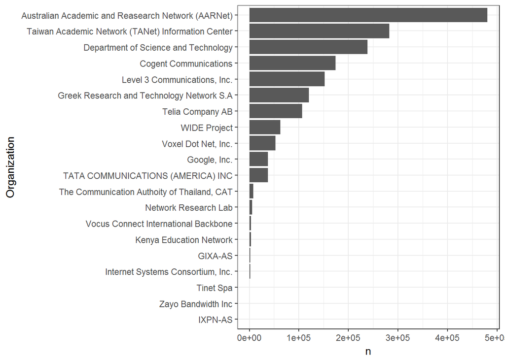

```r
mlab.3 %>%
  # group and taly by organization
  count(Org) %>%
  # arrange in descending order
  mutate(Org = reorder(Org, n)) %>%
  # choose the top 20 organizations
  top_n(20) %>%
  # plot
  ggplot(aes(Org, n)) +
  # the bar graph
  geom_bar(stat = "identity") +
  # change the x label
  xlab("Organization") +
  # I like the black and white theme
  theme_bw() +
  # flip the coordinates
  coord_flip()
```